# Effect of Region and Developed vs. Developing on COVID19 Death Rate

Alexa Aguirre ID#917483561

3/14/2022

# Abstract

This data analysis project will aim to determine if being a developing country and being in a specific region of the world is correlated to different mean death rate percentages due to the COVID-19 Pandemic. The COVID-19 data is obtained from the World Heath Organization and an additional source was used to classify countries as developed or developing. There are two factors that are being analyzed to see whether they effect death rate percentages. Factor A is classification with 2 levels (developed and developing) and factor B is region with 6 levels (Americas, Eastern Mediterranean, Western Pacific, South-East Asia, Africa, and Europe). First we will perform descriptive analysis and data visualization to obtain our data set and understand the distribution. Next, we fit the data set to a two way ANOVA model to further understand how region and classification effect death rates due to COVID 19 in countries. A logistic regression model will also be fit for prediction. Lastly, sensitivity analysis is performed to ensure that the dataset meets the assumptions of the model.

# Background/Introduction

The first case of COVID-19 was reported in December of 2019. The virus made its first appearance in the United States in January 2020 and has since surged through the worlds population at different rates and potency. With the virus being extremely transmittable and deathly, a vaccine has since been refined and administered to try and reduce the spread and fatality rate if infected. Countries have handled the pandemic in different fashions from initiating complete lock downs, mask mandates, and/or the requirement of being vaccinated to enter public establishments. How countries have decided to tackle the concerns of the pandemic have largely influenced infection and death rates in different places around the world. Different country economic standards and levels of development have also influenced how countries are able to provide for their citizens. Statistical data analysis pertaining to the pandemic has become largely popular to try and find answers and trends to the effects of the pandemic in hopes of bringing an end to the pandemic. The World Heath Organization has compiled a data-set that will be used throughout this project that takes daily statistics of infection and number of deaths in each country. Combining this data set with a country classification data set (https://www.un.org/development/desa/dpad/wp-content/uploads/sites/45/publication/WESP2022_web.pdf) we will aim to see if there is a correlation between region in the world, death rate, and whether the country has a developed economy or a developing economy. For this project, the countries that were classified as “in transition” in the data set will be considered developing countries. Some characteristics of countries with developing economies includes a low gross domestic product per person, low living standards, and low levels of industrialization. These characteristics may lead to less access to vaccines, as the cold supply chain to store the vaccines at low temperatures may be un-affordable and resources are not present. Additionally with a lesser developed economy, medical care for those infected may become less accessible and less advanced. With all of the factors going against developing countries during the pandemic is there actually a higher death percentage of those infected than countries that are considered developed and have more access to resources? It is expected to see that the death rate percentage of developed countries will be lower than those of undeveloped countries because they have more access to vaccines and advanced medicine.

# Descriptive Analysis/Summary Statistics

The World Health Organization data set shows each country going in alphabetical order and reports the new number of cases each day for that country as a new row entry. Along with the country and case number per day, cumulative cases, new deaths and cumulative deaths are also recorded each day.

```
##   Date_reported Country_code     Country WHO_region New_cases Cumulative_cases
## 1    2020-01-03           AF Afghanistan       EMRO         0                0
## 2    2020-01-04           AF Afghanistan       EMRO         0                0
## 3    2020-01-05           AF Afghanistan       EMRO         0                0
## 4    2020-01-06           AF Afghanistan       EMRO         0                0
## 5    2020-01-07           AF Afghanistan       EMRO         0                0
## 6    2020-01-08           AF Afghanistan       EMRO         0                0
##   New_deaths Cumulative_deaths
## 1          0                 0
## 2          0                 0
## 3          0                 0
## 4          0                 0
## 5          0                 0
## 6          0                 0
```

Above is the first six rows of the data to illustrate the format of the dataset. As we can see, it shows the first six days of data collected in Afghanistan. The data set is updated daily to include new cases, new deaths, and update the cumulative quantities.

```
## # A tibble: 229 × 4
##    Country             max_cases max_deaths death_rate_percentage
##    <chr>                   <int>      <int>                 <dbl>
##  1 Afghanistan            176201       7643                 4.34
##  2 Albania                272663       3485                 1.28
##  3 Algeria                265432       6864                 2.59
##  4 American Samoa            555          0                 0
##  5 Andorra                 38794        152                 0.392
##  6 Angola                  98927       1900                 1.92
##  7 Anguilla                 2574          9                 0.350
##  8 Antigua and Barbuda      7466        135                 1.81
##  9 Argentina             8971432     127187                 1.42
## 10 Armenia                422021       8576                 2.03
## # … with 219 more rows
```

The data set is now grouped by country to combine all of the days from the country into one row as the new cases variable will not be useful for the purpose of our data analysis. Now there will only be one row for each country instead of every country having a new row for a new day. The row for each country will now also show max cases, max deaths, and a new variable, death rate percentage is calculated in a new column by dividing deaths by cases so we can see the number of people who die based on the number who are infected. The variables are now country, max_cases which is the number or reported positive cases, max_deaths which is the total amount of deaths in the specific country and death_rate_percentage. This new variable will be helpful because since it is a percent, it eliminates the variability we will get due to the fact that every country has a different population number.

```
## # A tibble: 228 × 9
##    Country   max_cases max_deaths death_rate_perce… X             Classification
##    <chr>         <int>      <int>             <dbl> <chr>         <chr>
##  1 Afghanis…    176201       7643             4.34  "Afghanistan… Developing
##  2 Albania      272663       3485             1.28  "Albania    … Developing
##  3 Algeria      265432       6864             2.59  "Algeria    … Developing
##  4 American…       555          0             0     "American Sa… Developing
##  5 Andorra       38794        152             0.392 "Andorra    … Developed
##  6 Angola        98927       1900             1.92  "Angola     … Developing
##  7 Anguilla       2574          9             0.350 "Anguilla   … Developing
##  8 Antigua …      7466        135             1.81  "Antigua and… Developing
##  9 Argentina   8971432     127187             1.42  "Argentina  … Developing
## 10 Armenia      422021       8576             2.03  "Armenia    … Developing
## # … with 218 more rows, and 3 more variables: Doc.Classification <chr>,
## #   Region <chr>, Population..mil. <dbl>
```

Next, we will use a data set that the “World Economic Situations and Prospects” (WESP) uses to classify countries as developed, in transition, or developing economies. We joined this data set with our previous data set by country so that now each country will be classified as a developed or developing economy. For the purpose of our data analysis, countries classified as in transition by the data set will be reclassified into the developing category. Region and population were also added as new variables.

```
## # A tibble: 23 × 9
##    Country      max_cases max_deaths death_rate_perc… X           Classification
##    <chr>            <int>      <int>            <dbl> <chr>       <chr>
##  1 Holy See            26          0           0      "Holy See … Developed
##  2 San Marino       14726        112           0.761  "San Marin… Developed
##  3 Monaco            9778         51           0.522  "Monaco"    Developed
##  4 Liechtenste…     13933         76           0.545  "Liechtens… Developed
##  5 Northern Ma…     10379         30           0.289  "Northern … Developed
##  6 Guernsey         15630         31           0.198  "Guernsey … Developed
##  7 Andorra          38794        152           0.392  "Andorra  … Developed
##  8 Isle of Man      24488         81           0.331  "Isle of M… Developed
##  9 Jersey           40807        116           0.284  "Jersey   … Developed
## 10 Iceland         162938         81           0.0497 "Iceland  … Developed
## # … with 13 more rows, and 3 more variables: Doc.Classification <chr>,
## #   Region <chr>, Population..mil. <dbl>
```

This is a subset of our data that only includes countries classified as developed. We will then take the lowest half of the developed countries based on population so that we can work with a smaller data set. Our conclusions will be based on the lowest populations from both classification groups.

```
## # A tibble: 91 × 9
##    Country    max_cases max_deaths death_rate_perce… X            Classification
##    <chr>          <int>      <int>             <dbl> <chr>        <chr>
##  1 Niue               1          0            0      "Niue"       Developing
##  2 Saba             211          0            0      "Saba"       Developing
##  3 Falkland …       118          0            0      "Falkland I… Developing
##  4 Sint Eust…       472          3            0.636  "Sint Eusta… Developing
##  5 Montserrat       166          2            1.20   "Montserrat" Developing
##  6 Saint Pie…      1055          1            0.0948 "Saint Pier… Developing
##  7 Cook Isla…       338          0            0      "Cook Islan… Developing
##  8 Saint Bar…      3726          4            0.107  "Saint Bart… Developing
##  9 Wallis an…       453          7            1.55   "Wallis and… Developing
## 10 Palau           3899          6            0.154  "Palau"      Developing
## # … with 81 more rows, and 3 more variables: Doc.Classification <chr>,
## #   Region <chr>, Population..mil. <dbl>
```

Another subset of data is created that only contains countries classified as developing. We will once again take the lowest half of countries based on population to use for further data analysis.

```
## # A tibble: 114 × 3
##    Classification Region          death_rate_percentage
##    <chr>          <chr>                           <dbl>
##  1 Developed      Europe                         0
##  2 Developed      Europe                         0.761
##  3 Developed      Europe                         0.522
##  4 Developed      Europe                         0.545
##  5 Developed      Western Pacific                0.289
##  6 Developed      Europe                         0.198
##  7 Developed      Europe                         0.392
##  8 Developed      Europe                         0.331
##  9 Developed      Europe                         0.284
## 10 Developed      Europe                         0.0497
## # … with 104 more rows
```

The two subsets of the data are now combined back together in order to compare the lower half of developed countries based on population to the lower half of developing countries based on population. Since we are no longer interested in some of the variables in the original table, we will simplify the data set to contain our two independent categorical variables of classification and region, and our dependent quantitative variable of death rate percentage.

```
##   Classification death_rate_percentage
## 1      Developed             0.5436990
## 2     Developing             0.9803108
```

```
##                  Region death_rate_percentage
## 1                Africa             1.4934460
## 2              Americas             0.9397365
## 3 Eastern Mediterranean             0.7117213
## 4                Europe             0.9033758
## 5       South-East Asia             0.2578796
## 6       Western Pacific             0.4102204
```

The table shows the mean death rate percentage based on if the country is classified as a developed or developing economy. The average death rate percentage is seen to be higher in those classified as developing. Next we can see the mean death rates for every region. It appears that the death rate is the highest in Africa and lowest in South-East Asia.

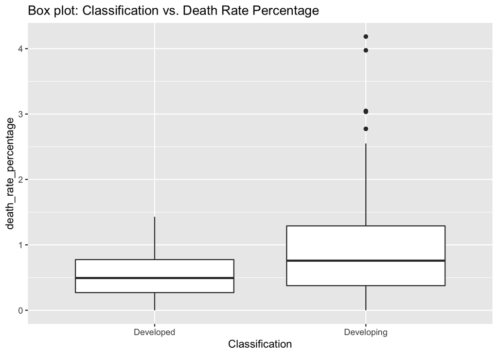

The box plot illustrates the inter quartile range of death rate percentages for developed and developing countries. Developed countries have a lower median and maximum value that developing countries. The IQR of the developed countries is also lower than that of developing countries.

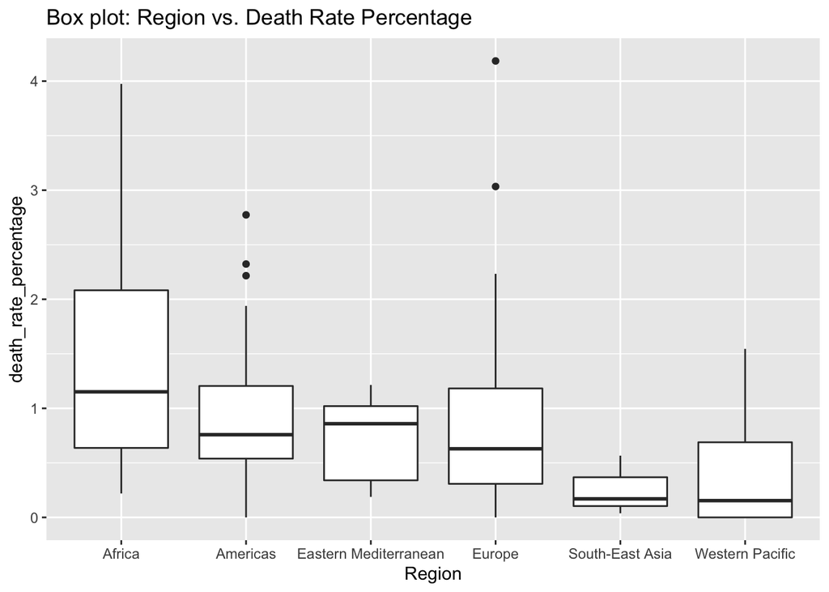

Looking at the box plots for death rate percentage by region, it appears that Europe has the highest death rate percentage but has an outlier value. Africa also has a high maximum death rate percentage. The median death rate for South-East Asia and the Western Pacific regions are the lowest.

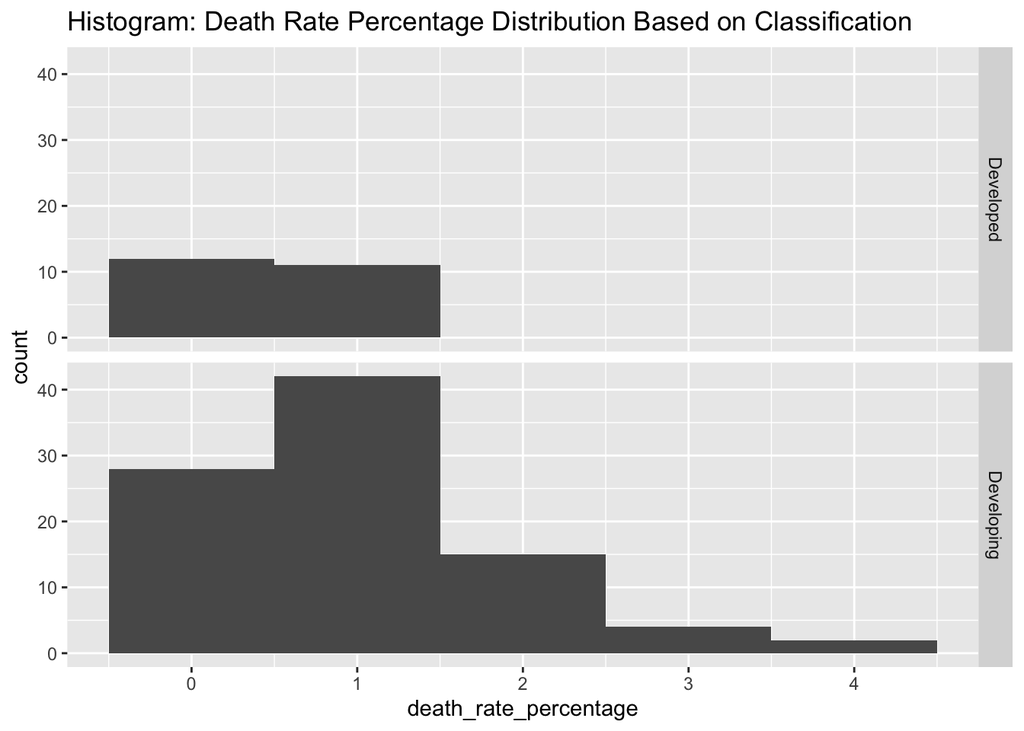

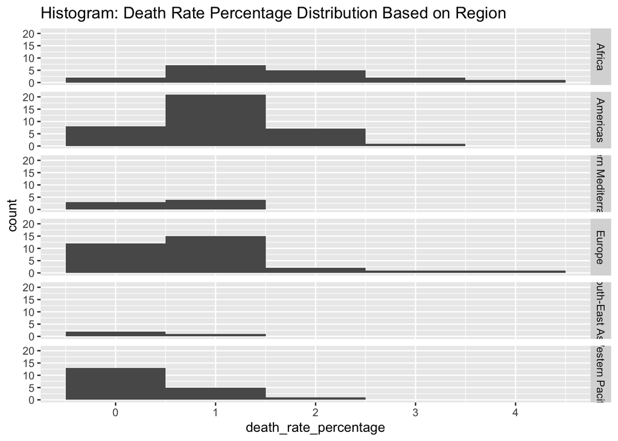

# Inferential Analysis

### Two Way ANOVA

First we will fit our data to a model to try and see the effects of classification and region on death rate. Since we have two factor levels, we will use a two way ANOVA model to determine if there is a difference in the mean based upon region and classification. We will first conduct a hypothesis test of ANOVA to see if there is an interaction effect or not.

Hypothesis Test: Ho, null hypothesis: The model with no interactions is statistically a better fit model than the model with interactions. All Gamma*Delta(ij) = 0

Ha, alternative hypothesis: The model with interactions is a statistically better fit than the model with no interactions. At least one Gamma*Delta(ij) != 0

Full model: Yijk = mu.. + gamma(i) + delta(j) + GammaDelta(ij) + epsilon(ijk) constraints: summation of gamma(i) = 0, summation of delta(j) = 0, summation for all i of GammaDelta(ij) = 0 = summation for all j of GammaDelta(ij)

Reduced model: Yijk = mu.. + gamma(i) + delta(j) + epsilon(ijk) with constraints: summation of gamma(i) = 0, summation of delta(j) = 0

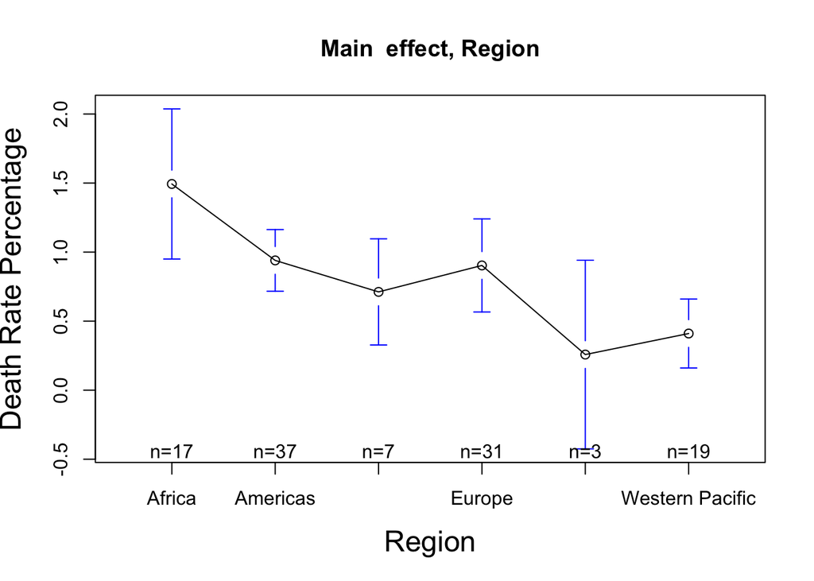

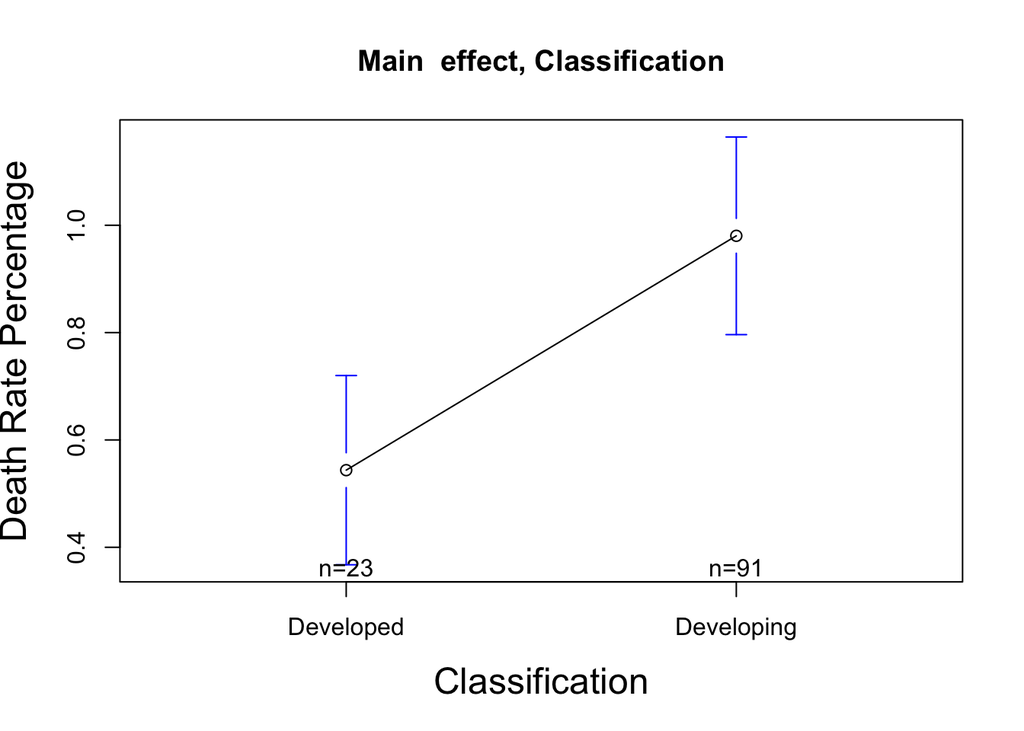

Here is a plot of the effect of region by itself on the dependent variable of death rate percentage. Africa has the highest average while South East Asia has the lowest. Additionally, there is a plot of the effect of classification by itself on the dependent variable of death rate percentage. We can see there are 23 developed observations and 91 developing. The mean death rate for developed is below .6 while the mean death rate for developing is below 1.

```
## Analysis of Variance Table
##
## Model 1: death_rate_percentage ~ as.factor(Classification) + as.factor(Region)
## Model 2: death_rate_percentage ~ as.factor(Classification) + as.factor(Region) +
##     as.factor(Classification) * as.factor(Region)
##   Res.Df    RSS Df Sum of Sq      F Pr(>F)
## 1    107 59.217
## 2    106 58.484  1   0.73243 1.3275 0.2518
```

```
## Anova Table (Type II tests)
##
## Response: death_rate_percentage
##                           Sum Sq  Df F value    Pr(>F)
## as.factor(Classification)  6.199   1 11.2018 0.0011283 **
## as.factor(Region)         14.781   5  5.3417 0.0002014 ***
## Residuals                 59.217 107
## ---
## Signif. codes:  0 '***' 0.001 '**' 0.01 '*' 0.05 '.' 0.1 ' ' 1
```

We will run an imbalanced ANOVA test since there are a different number of countries in each factor level. When running a type II sum of squares test for ANOVA we can see that p-values are relatively small compared to the significance level, proving that classification and region have a significant effect on the response variable, death rate percentage. Therefore, our final model will include both factor effects with no interaction terms.

Now that we know both parameters are significant, we will begin testing to determine which groups pairs of factor levels are different from one another and to see if there is a specific combination of region and classification that has the highest death rate percentage.

### Confidence Intervals

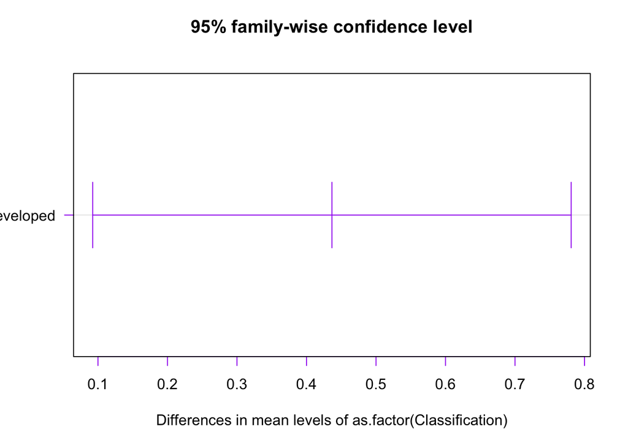

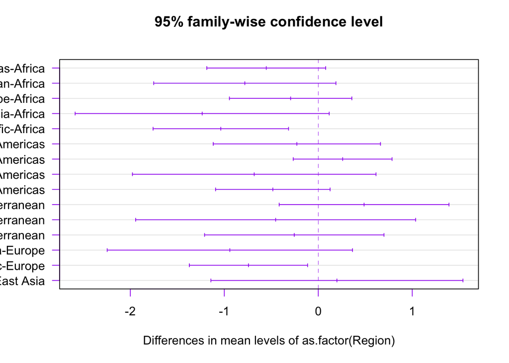

### Means depending on both factors

```
##              Africa  Americas Eastern Mediterranean    Europe South-East Asia
## Developed        NA        NA                    NA 0.5804263              NA
## Developing 1.493446 0.9397365             0.7117213 1.5815697       0.2578796
##            Western Pacific
## Developed        0.1580621
## Developing       0.4398861
```

This table illustrates the mean death rate percentage based upon both factors simultaneously. The NA entries means that there were no reported countries that fit into both factors. For example, there are no developed countries in Africa in the portion of data that we are using. Developed countries in the Western Pacific have the lowest death rate percentage while developing countries in Europe have the highest. It is also worthy to note that there are only developed countries in Europe and the Western Pacific and both numbers are relatively low compared to the death rate percentages in developing countries.

### Logistic Regression

```
##
## Call:
## glm(formula = Classification ~ death_rate_percentage, family = "binomial",
##     data = df)
##
## Deviance Residuals:
##     Min       1Q   Median       3Q      Max
## -2.0843   0.3009   0.5917   0.7372   0.9061
##
## Coefficients:
##                       Estimate Std. Error z value Pr(>|z|)
## (Intercept)             0.6780     0.3533   1.919   0.0550 .
## death_rate_percentage   0.9611     0.4372   2.199   0.0279 *
## ---
## Signif. codes:  0 '***' 0.001 '**' 0.01 '*' 0.05 '.' 0.1 ' ' 1
##
## (Dispersion parameter for binomial family taken to be 1)
##
##     Null deviance: 114.64  on 113  degrees of freedom
## Residual deviance: 108.07  on 112  degrees of freedom
## AIC: 112.07
##
## Number of Fisher Scoring iterations: 5
```

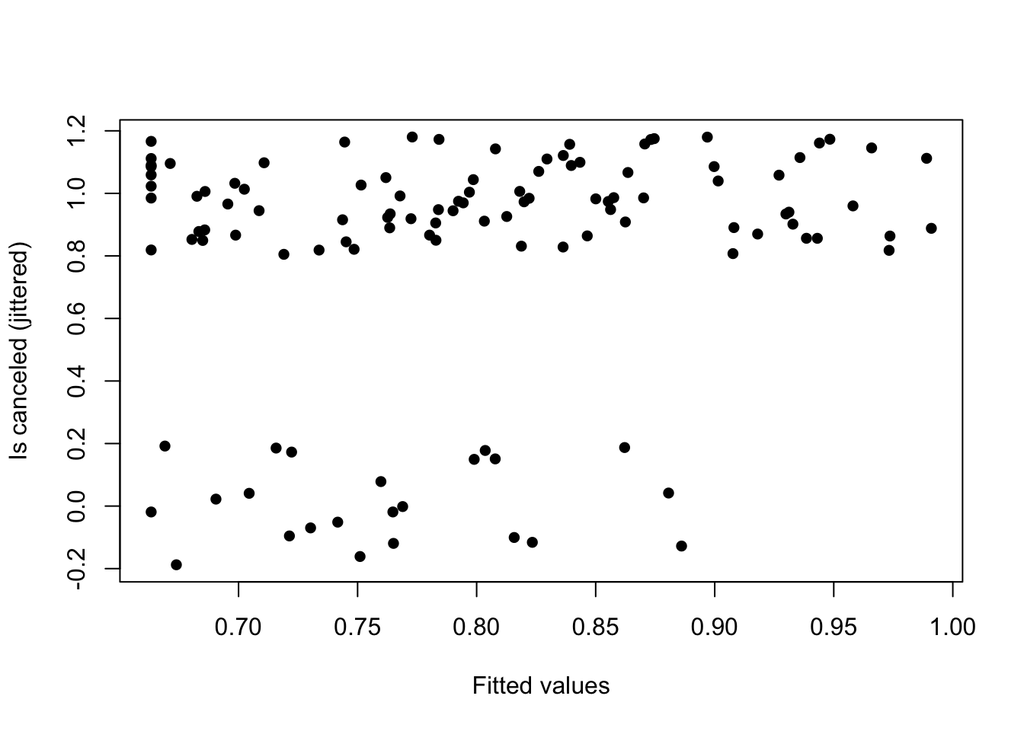

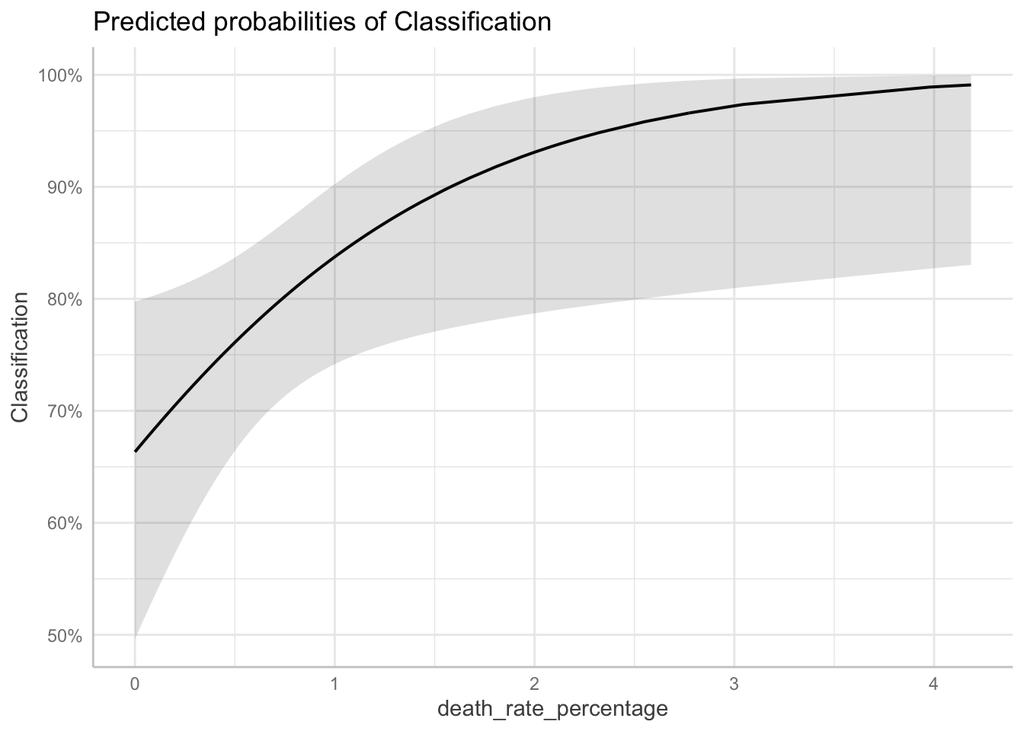

Above, a logistic regression model is created using a log likelihood ratio for prediction. The estimated parameter shows that the estimated log odds ratio of being classified as developing with a one unit change in death rate is 0.961. The graph shows that as death rate percentage increases, the more likely the country will be classified as developing.

# Sensitivity Analysis

We will check to see if the assumptions of two way ANOVA are met. Our assumptions for two-way ANOVA are that all subjects are randomly sampled and independent, all levels of factor A and factor B are independent, and the errors are normally distributed.

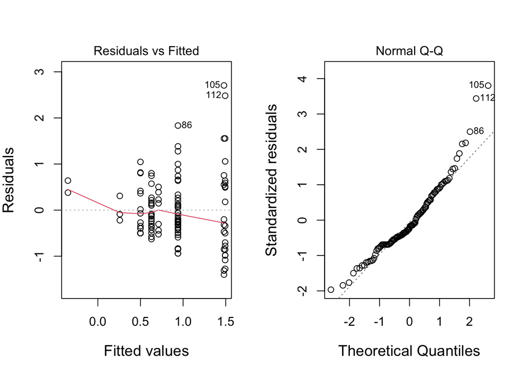

The Normal QQ plot illustrates that the assumption of normally distributes error terms as the points are close to creating a linear relationship. The varience of the residuals versus fitted values should be randomly distributed to show equal varience. There appears to be a slight pattern so we will run a Levene test for homogeneity to check our assumption.

```
## Levene's Test for Homogeneity of Variance (center = median)
##        Df F value   Pr(>F)
## group   7   3.329 0.003037 **
##       106
## ---
## Signif. codes:  0 '***' 0.001 '**' 0.01 '*' 0.05 '.' 0.1 ' ' 1
```

# Conclusion/Discussion

Being a developing country led to higher death rates potentially due to the fact that lower economic stability may lead to less access to vaccines as well as less access to proper medical care. Another thing to consider is that the original World Health Organization Data Set had missing values for smaller countries which we had to eliminate from our dataset. Having a full dataset may lead to different mean values.

To expand the project, clustering may be a useful classification tool to determine if clustering by kmeans and k nearest neighbors results in similar patterns as if we were to classify the points into developed and developing.

# Acknowledgements

TA: Xiawei Wang Partner: Curtis Pan

#R eferences

U.S. and World Population Clock. United States Census Bureau. (n.d.). Retrieved February 28, 2022, https://www.census.gov/popclock/world

World Health Organization. (n.d.). Who coronavirus (COVID-19) dashboard. World Health Organization. Retrieved February 28, 2022, https://covid19.who.int/

Zhenmin, L., Barcena, A., Grynspan, R., Alisjahbana, A. S., Songwe, V., Dashti, R., & Algayerova, O. (2022, January 13). World Economic Situation and Prospects 2022. Retrieved February 20, 2022, https://www.un.org/development/desa/dpad/wp-content/uploads/sites/45/publication/WESP2022_web.pdf

# Appendix

```r
#reading in data and functions
whocovid <- read.csv("https://covid19.who.int/WHO-COVID-19-global-data.csv")
fin_country_class <- read.csv("~/Documents/STA141A/fin_country_class.csv")
library(tidyverse)
library(dbplyr)
library(ggplot2)
library(gplots)
library(car)
library(readr)
library(ggeffects)

#printing out first 6 entries of data set
head(whocovid)

#combining the observations by country
data=whocovid%>%
  group_by(Country) %>%
  summarize(max_cases = max(Cumulative_cases, na.rm = TRUE),  #finding the cumulative cases and deaths for each country
            max_deaths = max(Cumulative_deaths))
data$death_rate_percentage=(data$max_deaths/data$max_cases)*100 #calculating death rate percentage based on number of cases and deaths in each country
filter.data=data%>%filter(is.na(death_rate_percentage)!=TRUE) #getting rid of NA values
filter.data

#create a new data set that classifies each country as developed or not developed, adds in region and population
new_data=inner_join(filter.data, fin_country_class, by=c("Country"))
new_data

#filter out only developed countries
dat.develop=new_data%>%filter(Classification=="Developed")%>%arrange(Population..mil.)
dat.develop=head(dat.develop,n=23)
dat.develop

#filter out developing countries
not.develop=new_data%>%filter(Classification=="Developing")%>%arrange(Population..mil.)
not.develop=head(not.develop,n=91)
not.develop

#combining the smaller pop. of developed with smaller pop. of developing
df1=rbind(dat.develop,not.develop)
df1=df1[c("Classification","Region", "death_rate_percentage","Population..mil.","max_cases")]
df1$pos_case_rate=((df1$max_cases/1000000)/df1$Population..mil.)*100
df=df1[c("Classification","Region", "death_rate_percentage")]
df

#finding mean death rate based on classification and region
aggregate(death_rate_percentage~Classification, data=df, mean)
aggregate(death_rate_percentage~Region, data=df, mean)

#Box plot classification vs. death rate
ggplot(data=df, mapping=aes(x=Classification, y=death_rate_percentage)) +
  geom_boxplot() +
  ggtitle("Box plot: Classification vs. Death Rate Percentage")+
  xlab("Classification") #creating a box plot of mean scores based on class type

#Box plot classification vs. death rate
ggplot(data=df, mapping=aes(x=Region, y=death_rate_percentage)) +
  geom_boxplot() +
  ggtitle("Box plot: Region vs. Death Rate Percentage")+
  xlab("Region") #creating a box plot of mean scores based on class type

#histograms
ggplot(df, aes(x=death_rate_percentage))+
  geom_histogram(binwidth = 1) +
  facet_grid(Classification ~.) +
  ggtitle("Histogram: Death Rate Percentage Distribution Based on Classification")\
ggplot(df, aes(x=death_rate_percentage))+
  geom_histogram(binwidth = 1) +
  facet_grid(Region ~.) +
  ggtitle("Histogram: Death Rate Percentage Distribution Based on Region")

#Main effect
plotmeans(death_rate_percentage~Region,data=df,xlab="Region",ylab="Death Rate Percentage",
          main="Main  effect, Region",cex.lab=1.5)
plotmeans(death_rate_percentage~Classification,data=df,xlab="Classification",ylab="Death Rate Percentage",
          main="Main  effect, Classification",cex.lab=1.5)

#Test for interaction
full_model=lm(death_rate_percentage~as.factor(Classification)+as.factor(Region)+as.factor(Classification)*as.factor(Region),data=df);
reduced_model=lm(death_rate_percentage~as.factor(Classification)+as.factor(Region),data=df);
anova(reduced_model,full_model)

#F Test
res2=lm(death_rate_percentage~as.factor(Classification)+as.factor(Region),data=df)
anova.model=Anova(res2, type = 2)
anova.model

#Confidence Intervals
sig.level=0.05;
T.ci=TukeyHSD(aov(res2),conf.level = 1-sig.level)
par(mfrow=c(1,1))
plot(T.ci, las=1 , col="purple")
par(mfrow=c(1,1))

#mean death percentage of region given classification
idx=list();
idx[[1]]=df$Classification;idx[[2]]=df$Region;
(means.comb=tapply( df$death_rate_percentage, INDEX=idx,mean))

#creating logistic regression model
df$Classification = as.factor(df$Classification)
mod.can.lg<-glm(Classification~death_rate_percentage,data=df,family="binomial")
summary(mod.can.lg)
plot(jitter(mod.can.lg$y)~mod.can.lg$fitted.values,pch=16,xlab="Fitted values", ylab="Is canceled (jittered)")
threshold = 0.5;
plot(ggpredict(mod.can.lg,"death_rate_percentage[all]"))

#Sensetivity Analysis Plots
options(repr.plot.width=12, repr.plot.height=6)
par(mfrow=c(1,2))
plot(aov(res2),cex.lab=1.2,which=1:2)
par(mfrow=c(1,1))

#Levene Test
leveneTest(death_rate_percentage~Classification*Region,data=df)
```